# Practicum II / Part B

DA5030 / Multiple Linear Regression

Daware, Aditya

Spring, 2025

## Reading the CSV file

```r
url.train <- "https://s3.us-east-2.amazonaws.com/artificium.us/datasets/synth-data.csv"
url.valid <- "https://s3.us-east-2.amazonaws.com/artificium.us/datasets/synth-data-validation-500.csv"

df <- read.csv(url.train, stringsAsFactors = F)

df.valid <- read.csv(url.valid, stringsAsFactors = F)
```

The CSV file is read and stored in the variables, df and df.valid.

## Exploratory Data Analysis

```r
head(df)
```

```
##   X       N1       N2    B1     C1          N3 N4 N5       N6   Target
## 1 1 54.96714 16.82366 False Level4 2.113105732  1 15 34.01712 179.4131
## 2 2 48.61736 18.99347 False Level3 2.153364870  1 12 29.66952 163.2710
## 3 3 56.47689 46.07122  True Level1 3.915496313  3 12 32.21371 223.6947
## 4 4 65.23030 28.62799 False Level4 2.418500038  6  5 24.65979 209.7426
## 5 5 47.65847 24.74630  True Level3 0.007133728  3 10 12.63550 180.8885
## 6 6 47.65863 64.52376  True Level4 6.579590037  2  2 17.54872 221.6232
```

```r
head(df.valid)
```

```
##      X       N1       N2    B1     C1         N3 N4 N5        N6   Target
## 1 4005 36.33142 12.65445 False Level1 19.8813680  0  7 13.248527 106.7197
## 2 1967 48.02662 70.86767  True Level4  0.9360599  3  6 15.689272 239.7623
## 3 4425 40.99410  4.78656  True Level4  2.3667114  1  9 48.989721 124.7642
## 4 3101 42.93107 72.55682 False Level3  2.9295032  0  9 15.433314 228.3613
## 5 2513 55.48884 43.90292  True Level2 20.1594996  2  2 14.013002 198.3064
## 6 2555 41.31707 27.24672  True Level2  1.8271656  2  2  9.193541 139.3199
```

```r
str(df)
```

```
## 'data.frame':    4500 obs. of  10 variables:
##  $ X     : int  1 2 3 4 5 6 7 8 10 11 ...
##  $ N1    : num  55 48.6 56.5 65.2 47.7 ...
##  $ N2    : num  16.8 19 46.1 28.6 24.7 ...
##  $ B1    : chr  "False" "False" "True" "False" ...
##  $ C1    : chr  "Level4" "Level3" "Level1" "Level4" ...
##  $ N3    : num  2.11311 2.15336 3.9155 2.4185 0.00713 ...
##  $ N4    : int  1 1 3 6 3 2 2 2 3 1 ...
##  $ N5    : int  15 12 12 5 10 2 8 5 13 13 ...
##  $ N6    : num  34 29.7 32.2 24.7 12.6 ...
##  $ Target: num  179 163 224 210 181 ...
```

```r
str(df.valid)
```

```
## 'data.frame':    500 obs. of  10 variables:
##  $ X     : int  4005 1967 4425 3101 2513 2555 1097 2825 1495 1624 ...
##  $ N1    : num  36.3 48 41 42.9 55.5 ...
##  $ N2    : num  12.65 70.87 4.79 72.56 43.9 ...
##  $ B1    : chr  "False" "True" "True" "False" ...
##  $ C1    : chr  "Level1" "Level4" "Level4" "Level3" ...
##  $ N3    : num  19.881 0.936 2.367 2.93 20.159 ...
##  $ N4    : int  0 3 1 0 2 2 4 6 2 4 ...
##  $ N5    : int  7 6 9 9 2 2 11 19 14 13 ...
##  $ N6    : num  13.2 15.7 49 15.4 14 ...
##  $ Target: num  107 240 125 228 198 ...
```

```r
summary(df)
```

```
##        X              N1              N2                B1
##  Min.   :   1   Min.   :17.59   Min.   : 0.00528   Length:4500
##  1st Qu.:1258   1st Qu.:43.48   1st Qu.:24.98932   Class :character
##  Median :2514   Median :50.15   Median :49.09720   Mode  :character
##  Mean   :2506   Mean   :50.07   Mean   :49.36439
##  3rd Qu.:3749   3rd Qu.:56.62   3rd Qu.:73.66912
##  Max.   :5000   Max.   :89.26   Max.   :99.96732
##       C1                  N3                 N4              N5
##  Length:4500        Min.   : 0.00126   Min.   : 0.00   Min.   : 1.000
##  Class :character   1st Qu.: 1.56758   1st Qu.: 2.00   1st Qu.: 5.000
##  Mode  :character   Median : 3.62224   Median : 3.00   Median :10.000
##                     Mean   : 5.13949   Mean   : 2.99   Mean   : 9.896
##                     3rd Qu.: 6.96442   3rd Qu.: 4.00   3rd Qu.:15.000
##                     Max.   :46.10079   Max.   :11.00   Max.   :19.000
##        N6              Target
##  Min.   : 0.1224   Min.   : 57.81
##  1st Qu.:16.0661   1st Qu.:170.44
##  Median :25.8817   Median :207.50
##  Mean   :28.2671   Mean   :208.44
##  3rd Qu.:38.4099   3rd Qu.:246.99
##  Max.   :89.5951   Max.   :343.39
```

```r
summary(df.valid)
```

```
##        X              N1              N2               B1
##  Min.   :   9   Min.   :21.45   Min.   : 0.0943   Length:500
##  1st Qu.:1128   1st Qu.:43.00   1st Qu.:26.4323   Class :character
##  Median :2414   Median :49.87   Median :50.4416   Mode  :character
##  Mean   :2454   Mean   :49.89   Mean   :50.5466
##  3rd Qu.:3770   3rd Qu.:56.82   3rd Qu.:75.4198
##  Max.   :4994   Max.   :82.43   Max.   :99.8421
##       C1                  N3                 N4             N5
##  Length:500         Min.   : 0.01778   Min.   :0.00   Min.   : 1.000
##  Class :character   1st Qu.: 1.59016   1st Qu.:2.00   1st Qu.: 5.000
##  Mode  :character   Median : 3.54329   Median :3.00   Median : 9.500
##                     Mean   : 5.26433   Mean   :3.01   Mean   : 9.734
##                     3rd Qu.: 7.37634   3rd Qu.:4.00   3rd Qu.:15.000
##                     Max.   :29.65570   Max.   :9.00   Max.   :19.000
##        N6             Target
##  Min.   : 1.718   Min.   : 70.27
##  1st Qu.:15.405   1st Qu.:174.45
##  Median :26.159   Median :210.37
##  Mean   :28.854   Mean   :209.78
##  3rd Qu.:39.184   3rd Qu.:248.35
##  Max.   :82.651   Max.   :346.91
```

## Missing Values and Outliers

```r
sum(is.na(df))
```

```
## [1] 0
```

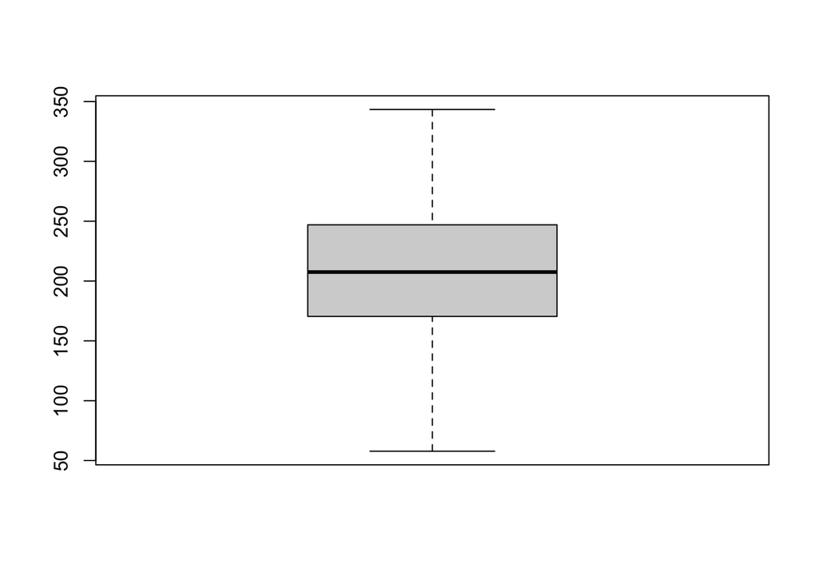

```r
boxplot(df$Target)
```

There are no missing values in the dataset. We checked the distribution of the dataset using boxplot and no outliers were found.

## Multicolinearity Check

```r
library(car)
vif(lm(Target ~ ., data = df))
```

```
##        GVIF Df GVIF^(1/(2*Df))
## X  1.004428  1        1.002211
## N1 1.001718  1        1.000859
## N2 1.001444  1        1.000722
## B1 1.004797  1        1.002396
## C1 1.011047  3        1.001833
## N3 1.001316  1        1.000658
## N4 1.004934  1        1.002464
## N5 1.002636  1        1.001317
## N6 1.002681  1        1.001340
```

Calculated the Variance Inflation Factor to check for multicolinearity in the data. If the value is close to 1 then it indicates low colinearity.VIF values greater than 10 may indicate multicollinearity issues.

### Scaling numeric features

#### Training Dataset

```r
numeric_cols <- sapply(df, is.numeric)
df[numeric_cols] <- scale(df[numeric_cols])
```

Scaling the features in the training dataset

#### Validation Dataset

```r
numeric_cols <- sapply(df.valid, is.numeric)
df.valid[numeric_cols] <- scale(df.valid[numeric_cols])
```

Scaling the features in the validation dataset

### Encoding categorical features

#### Training Dataset

```r
df <- cbind(df, model.matrix(~B1 - 1, data = df))
df <- df[, -which(names(df) == "B1")]

df <- cbind(df, model.matrix(~C1 - 1, data = df))
df <- df[, -which(names(df) == "C1")]
```

The model.matrix converts the variables into dummy variables and ensures that each level of the factor is represented as a seperate binary column.

#### Validation Dataset

```r
df.valid <- cbind(df.valid, model.matrix(~B1 - 1, data = df.valid))
df.valid <- df.valid[, -which(names(df.valid) == "B1")]

df.valid <- cbind(df.valid, model.matrix(~C1 - 1, data = df.valid))
df.valid <- df.valid[, -which(names(df.valid) == "C1")]
```

The model.matrix converts the variables into dummy variables and ensures that each level of the factor is represented as a seperate binary column.

## Feature selection

```r
model_full <- lm(Target ~ ., data = df)
step_model <- step(model_full, direction = "both")
```

```
## Start:  AIC=-20707.21
## Target ~ X + N1 + N2 + N3 + N4 + N5 + N6 + B1False + B1True +
##     C1Level1 + C1Level2 + C1Level3 + C1Level4
##
##
## Step:  AIC=-20707.21
## Target ~ X + N1 + N2 + N3 + N4 + N5 + N6 + B1False + B1True +
##     C1Level1 + C1Level2 + C1Level3
##
##
## Step:  AIC=-20707.21
## Target ~ X + N1 + N2 + N3 + N4 + N5 + N6 + B1False + C1Level1 +
##     C1Level2 + C1Level3
##
##            Df Sum of Sq    RSS      AIC
## - X         1       0.0   44.9 -20709.2
## - N6        1       0.0   44.9 -20709.1
## - B1False   1       0.0   44.9 -20709.0
## - C1Level1  1       0.0   44.9 -20709.0
## - C1Level3  1       0.0   44.9 -20708.3
## - C1Level2  1       0.0   44.9 -20707.5
## <none>                    44.9 -20707.2
## - N4        1       1.5   46.4 -20563.7
## - N3        1      28.3   73.3 -18507.9
## - N5        1      77.0  121.9 -16216.6
## - N1        1    1083.7 1128.6  -6201.9
## - N2        1    3217.8 3262.7  -1424.8
##
## Step:  AIC=-20709.19
## Target ~ N1 + N2 + N3 + N4 + N5 + N6 + B1False + C1Level1 + C1Level2 +
##     C1Level3
##
##            Df Sum of Sq    RSS      AIC
## - N6        1       0.0   44.9 -20711.1
## - B1False   1       0.0   44.9 -20711.0
## - C1Level1  1       0.0   44.9 -20711.0
## - C1Level3  1       0.0   44.9 -20710.3
## - C1Level2  1       0.0   44.9 -20709.5
## <none>                    44.9 -20709.2
## + X         1       0.0   44.9 -20707.2
```

[output cut: 83 more lines]

```
##            Df Sum of Sq    RSS      AIC
## <none>                    44.9 -20716.9
## + C1Level4  1       0.0   44.9 -20716.0
## + C1Level2  1       0.0   44.9 -20716.0
## + C1Level1  1       0.0   44.9 -20715.1
## + C1Level3  1       0.0   44.9 -20715.1
## + B1False   1       0.0   44.9 -20715.0
## + B1True    1       0.0   44.9 -20715.0
## + N6        1       0.0   44.9 -20715.0
## + X         1       0.0   44.9 -20714.9
## - N4        1       1.5   46.4 -20573.6
## - N3        1      28.4   73.3 -18516.5
## - N5        1      77.1  122.1 -16223.0
## - N1        1    1084.9 1129.9  -6208.9
## - N2        1    3219.8 3264.8  -1434.0
```

```r
summary(step_model)
```

```
##
## Call:
## lm(formula = Target ~ N1 + N2 + N3 + N4 + N5, data = df)
##
## Residuals:
##      Min       1Q   Median       3Q      Max
## -0.33682 -0.06653 -0.00106  0.06875  0.34140
##
## Coefficients:
##               Estimate Std. Error t value Pr(>|t|)
## (Intercept) -1.416e-15  1.491e-03    0.00        1
## N1           4.912e-01  1.491e-03  329.37   <2e-16 ***
## N2           8.463e-01  1.492e-03  567.41   <2e-16 ***
## N3          -7.944e-02  1.491e-03  -53.27   <2e-16 ***
## N4           1.811e-02  1.491e-03   12.14   <2e-16 ***
## N5           1.310e-01  1.491e-03   87.81   <2e-16 ***
## ---
## Signif. codes:  0 '***' 0.001 '**' 0.01 '*' 0.05 '.' 0.1 ' ' 1
##
## Residual standard error: 0.1 on 4494 degrees of freedom
## Multiple R-squared:   0.99,  Adjusted R-squared:   0.99
## F-statistic: 8.907e+04 on 5 and 4494 DF,  p-value: < 2.2e-16
```

This code chunk runs a full linear regression model using all features in the training dataset. Then, stepwise feature selection is performed in both forward and backward directions to identify the most relevant variables for predicting the target. The summary displays the results of the selected model.

## Model Training

### Model 1

```r
model1 <- lm(Target ~ X + N1 + N2 + N3 + N4 + N5 + N6 + B1False + B1True + C1Level1 + C1Level2 + C1Level3 + C1Level4, data = df)
summary(model1)
```

```
##
## Call:
## lm(formula = Target ~ X + N1 + N2 + N3 + N4 + N5 + N6 + B1False +
##     B1True + C1Level1 + C1Level2 + C1Level3 + C1Level4, data = df)
##
## Residuals:
##      Min       1Q   Median       3Q      Max
## -0.33882 -0.06713 -0.00058  0.06871  0.34135
##
## Coefficients: (2 not defined because of singularities)
##               Estimate Std. Error t value Pr(>|t|)
## (Intercept)  0.0022476  0.0033310   0.675    0.500
## X           -0.0001938  0.0014949  -0.130    0.897
## N1           0.4912108  0.0014928 329.046   <2e-16 ***
## N2           0.8463208  0.0014926 567.000   <2e-16 ***
## N3          -0.0794241  0.0014925 -53.214   <2e-16 ***
## N4           0.0181565  0.0014952  12.143   <2e-16 ***
## N5           0.1309842  0.0014935  87.702   <2e-16 ***
## N6           0.0005398  0.0014936   0.361    0.718
## B1False      0.0011860  0.0029900   0.397    0.692
## B1True              NA         NA      NA       NA
## C1Level1    -0.0017365  0.0042378  -0.410    0.682
## C1Level2    -0.0055371  0.0042158  -1.313    0.189
## C1Level3    -0.0040518  0.0042482  -0.954    0.340
## C1Level4            NA         NA      NA       NA
## ---
## Signif. codes:  0 '***' 0.001 '**' 0.01 '*' 0.05 '.' 0.1 ' ' 1
##
## Residual standard error: 0.1 on 4488 degrees of freedom
## Multiple R-squared:   0.99,  Adjusted R-squared:   0.99
## F-statistic: 4.045e+04 on 11 and 4488 DF,  p-value: < 2.2e-16
```

### Model 2

```r
model2 <- lm(Target ~ X + N1 + N2 + N3 + N4 + N5 + N6 + B1False + B1True + C1Level1 + C1Level2 + C1Level3, data = df)
summary(model2)
```

```
##
## Call:
## lm(formula = Target ~ X + N1 + N2 + N3 + N4 + N5 + N6 + B1False +
##     B1True + C1Level1 + C1Level2 + C1Level3, data = df)
##
## Residuals:
##      Min       1Q   Median       3Q      Max
## -0.33882 -0.06713 -0.00058  0.06871  0.34135
##
## Coefficients: (1 not defined because of singularities)
##               Estimate Std. Error t value Pr(>|t|)
## (Intercept)  0.0022476  0.0033310   0.675    0.500
## X           -0.0001938  0.0014949  -0.130    0.897
## N1           0.4912108  0.0014928 329.046   <2e-16 ***
## N2           0.8463208  0.0014926 567.000   <2e-16 ***
## N3          -0.0794241  0.0014925 -53.214   <2e-16 ***
## N4           0.0181565  0.0014952  12.143   <2e-16 ***
## N5           0.1309842  0.0014935  87.702   <2e-16 ***
## N6           0.0005398  0.0014936   0.361    0.718
## B1False      0.0011860  0.0029900   0.397    0.692
## B1True              NA         NA      NA       NA
## C1Level1    -0.0017365  0.0042378  -0.410    0.682
## C1Level2    -0.0055371  0.0042158  -1.313    0.189
## C1Level3    -0.0040518  0.0042482  -0.954    0.340
## ---
## Signif. codes:  0 '***' 0.001 '**' 0.01 '*' 0.05 '.' 0.1 ' ' 1
##
## Residual standard error: 0.1 on 4488 degrees of freedom
## Multiple R-squared:   0.99,  Adjusted R-squared:   0.99
## F-statistic: 4.045e+04 on 11 and 4488 DF,  p-value: < 2.2e-16
```

### Model 3

```r
model3 <- lm(Target ~ X + N1 + N2 + N3 + N4 + N5 + N6 + B1False + C1Level1 + C1Level2 + C1Level3, data = df)
summary(model3)
```

```
##
## Call:
## lm(formula = Target ~ X + N1 + N2 + N3 + N4 + N5 + N6 + B1False +
##     C1Level1 + C1Level2 + C1Level3, data = df)
##
## Residuals:
##      Min       1Q   Median       3Q      Max
## -0.33882 -0.06713 -0.00058  0.06871  0.34135
##
## Coefficients:
##               Estimate Std. Error t value Pr(>|t|)
## (Intercept)  0.0022476  0.0033310   0.675    0.500
## X           -0.0001938  0.0014949  -0.130    0.897
## N1           0.4912108  0.0014928 329.046   <2e-16 ***
## N2           0.8463208  0.0014926 567.000   <2e-16 ***
## N3          -0.0794241  0.0014925 -53.214   <2e-16 ***
## N4           0.0181565  0.0014952  12.143   <2e-16 ***
## N5           0.1309842  0.0014935  87.702   <2e-16 ***
## N6           0.0005398  0.0014936   0.361    0.718
## B1False      0.0011860  0.0029900   0.397    0.692
## C1Level1    -0.0017365  0.0042378  -0.410    0.682
## C1Level2    -0.0055371  0.0042158  -1.313    0.189
## C1Level3    -0.0040518  0.0042482  -0.954    0.340
## ---
## Signif. codes:  0 '***' 0.001 '**' 0.01 '*' 0.05 '.' 0.1 ' ' 1
##
## Residual standard error: 0.1 on 4488 degrees of freedom
## Multiple R-squared:   0.99,  Adjusted R-squared:   0.99
## F-statistic: 4.045e+04 on 11 and 4488 DF,  p-value: < 2.2e-16
```

## Ensemble approach

```r
predictions_model1 <- predict(model1, newdata = df.valid)
predictions_model2 <- predict(model2, newdata = df.valid)
predictions_model3 <- predict(model3, newdata = df.valid)

ensemble_predictions <- (predictions_model1 + predictions_model2 + predictions_model3) / 3

# Fit a new model using the ensemble predictions as the target
ensemble_model <- lm(ensemble_predictions ~ X + N1 + N2 + N3 + N4 + N5 + N6 + B1False + B1True + C1Level1 + C1Level2 + C1Level3 + C1Level4, data = df.valid)
```

This section first predicts the target variable using each of the three models. Then, an ensemble prediction is created by averaging the predictions from all three models. A new linear regression model is built using the ensemble predictions as the target variable.

## Model Validation

### Prediction

```r
validation_predictions <- predict(ensemble_model, newdata = df.valid)
```

### MSE

```r
mse <- mean((df.valid$Target - validation_predictions)^2)
mse
```

```
## [1] 0.01126757
```

The Mean Squared Error was found to be 0.0112676. Lower value indicates better model performance.

## Normality of residuals

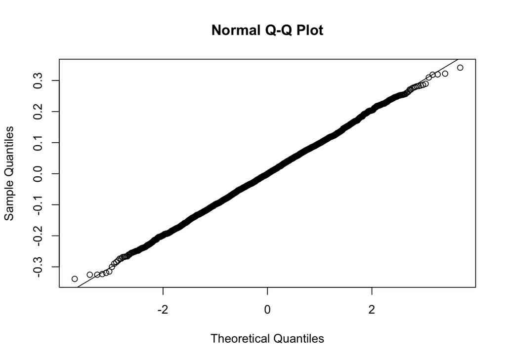

```r
qqnorm(residuals(model1))
qqline(residuals(model1))
```

The QQ plot checks the normality of the residuals. The straight line indicates that they are normally distributed.

## Normality of residuals

```r
shapiro.test(residuals(model1))
```

```
##
##  Shapiro-Wilk normality test
##
## data:  residuals(model1)
## W = 0.99962, p-value = 0.5678
```

The Shapiro-Wilk test is performed to formally test the normality of residuals. A significant p-value (typically less than 0.05) would indicate that the residuals are not normally distributed, which could suggest issues with the model.